# How Gaming Affects Well-being

Sandy, Fredy, Benjamin

2026-04-19

# Introduction

**Domain Question:** How does gaming affect our well-being?

*Sub-questions:* Does high gaming intensity correlate with anxiety (GAD)?

How does gaming affect social interaction & social anxiety (SPIN)?

How does gaming affect Life Satisfaction (SWL)?

# Data Overview

- Authentic data
- Surveyed individuals
- Thousands of entries (Large Dataset)

A look at our sample’s gaming habits.

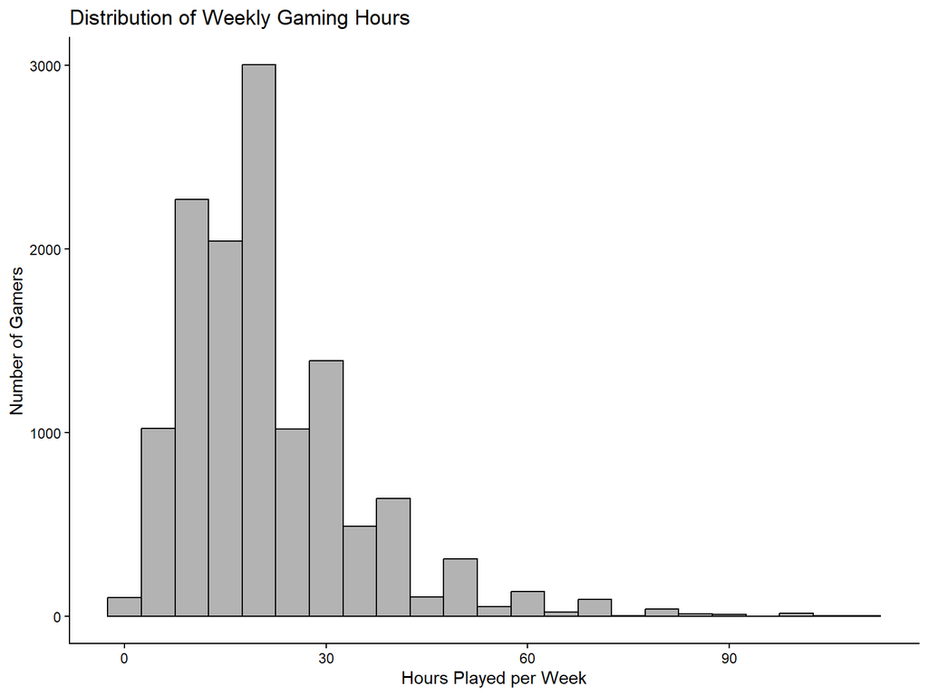

# Psychological Effects of Gaming

**Anxiety**

Does more gaming mean more anxiety?

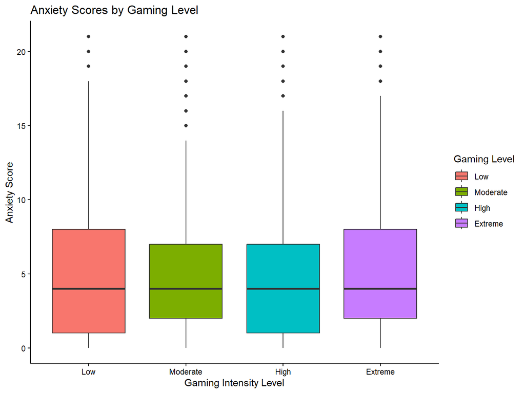

**Average Anxiety**

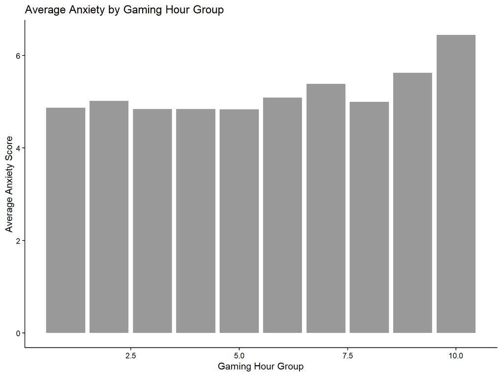

**Anxiety by Residence**

Anxiety may not be caused by gaming alone.

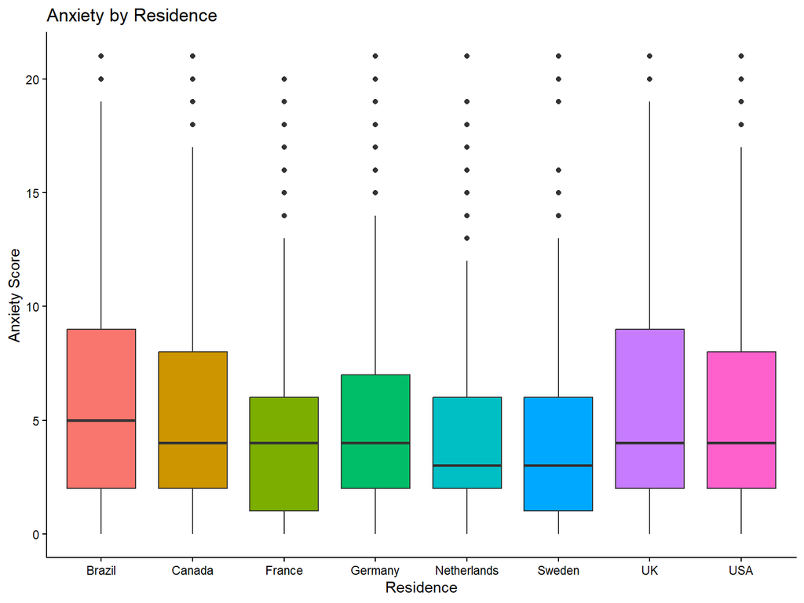

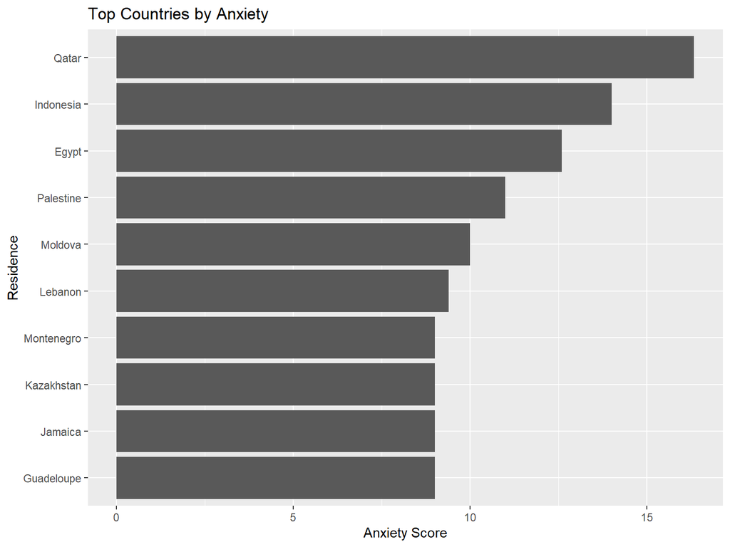

# Why do People play Games?

**What are the primary drivers for gaming?**

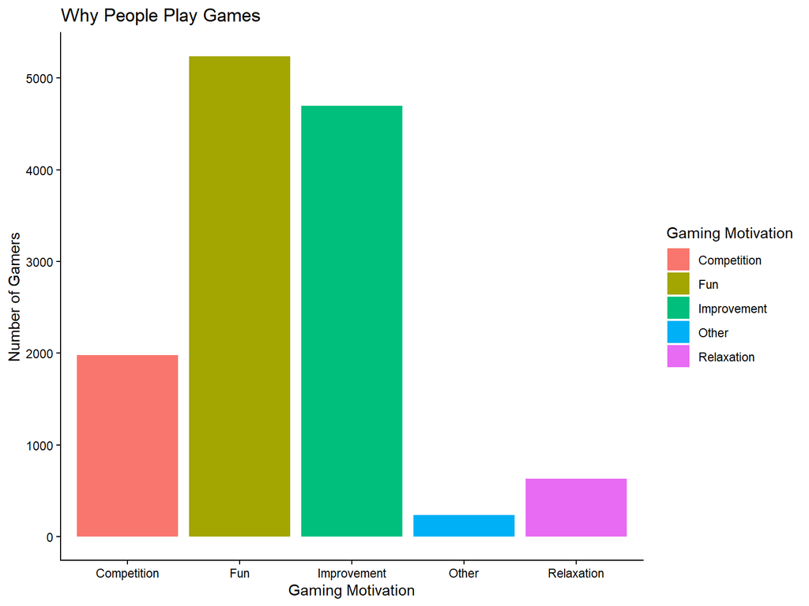

Why you play and who you play with might matter more than how long you play.

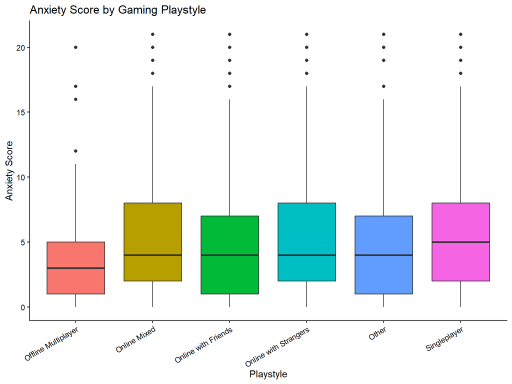

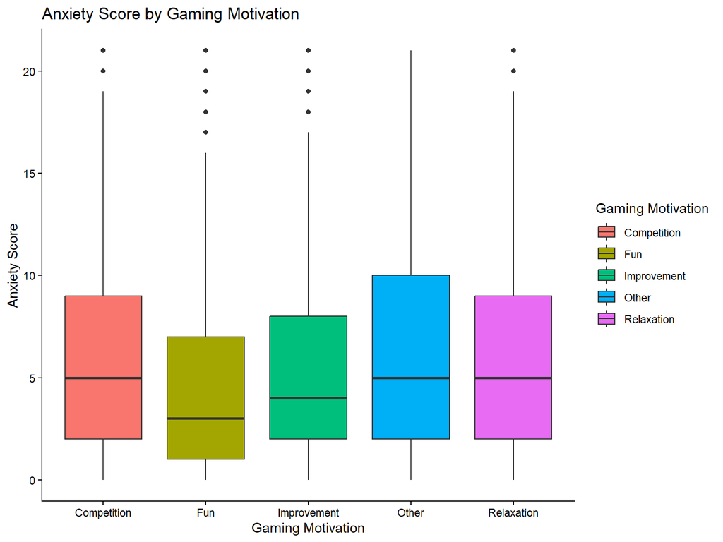

# Social Effects of Gaming

We compared social anxiety scores across different playstyles to see how who you play with affects your gaming experience.

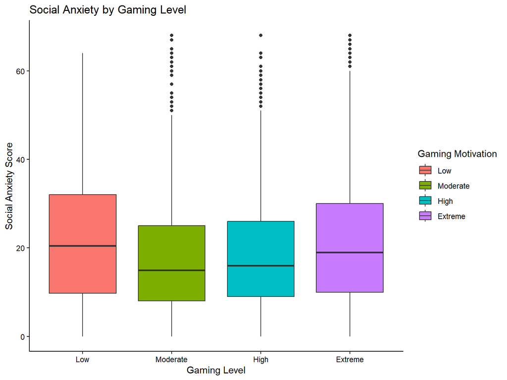

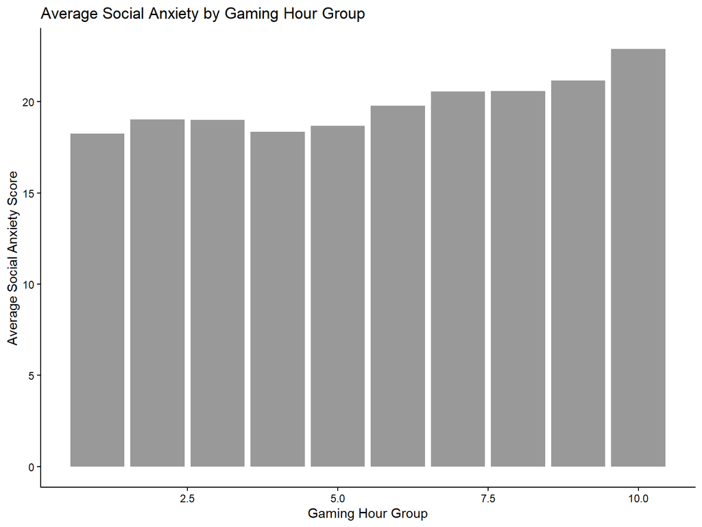

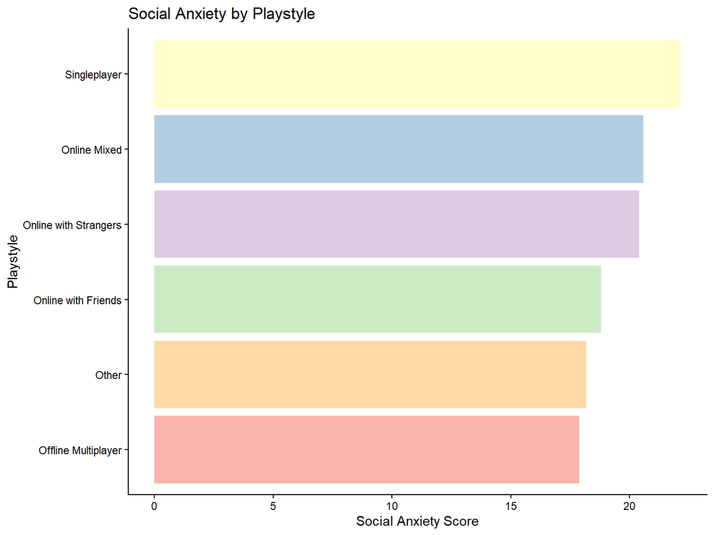

# Life Satisfaction

**How does gaming affects happiness?**

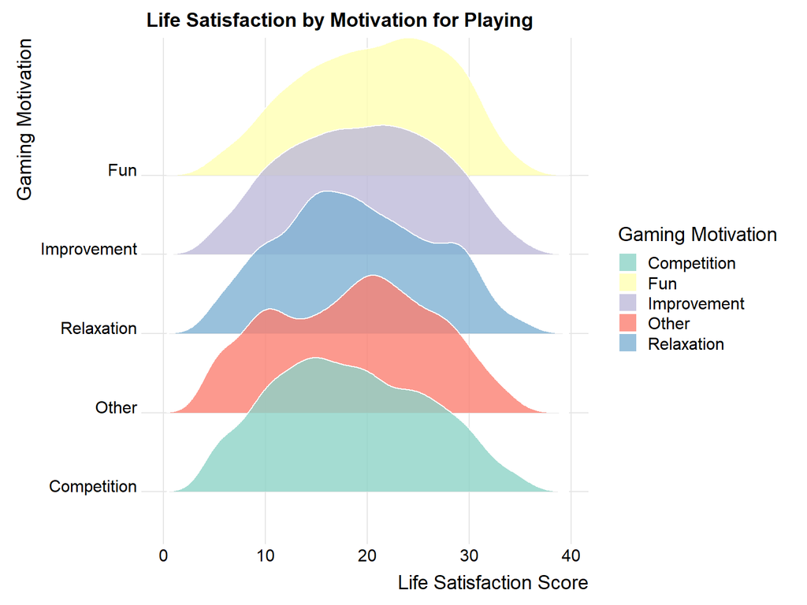

[figure not shown]

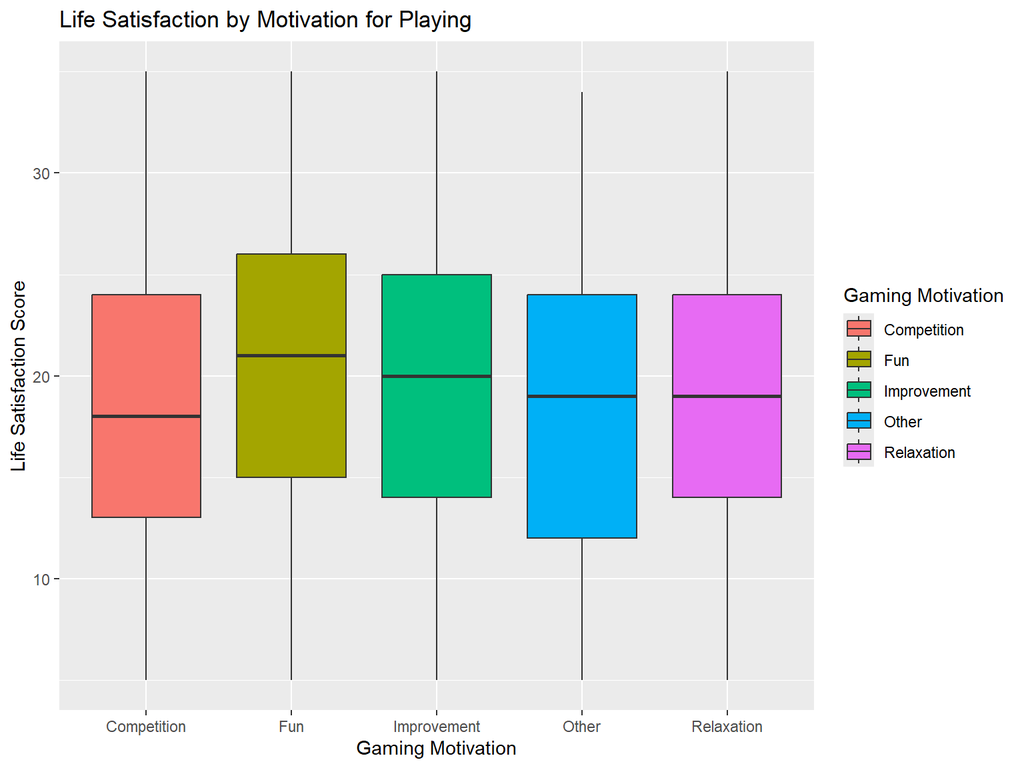

# Demographic Trends

**Who is playing and how does it affect them?**

Is high-intensity gaming more stressful for older or younger people?

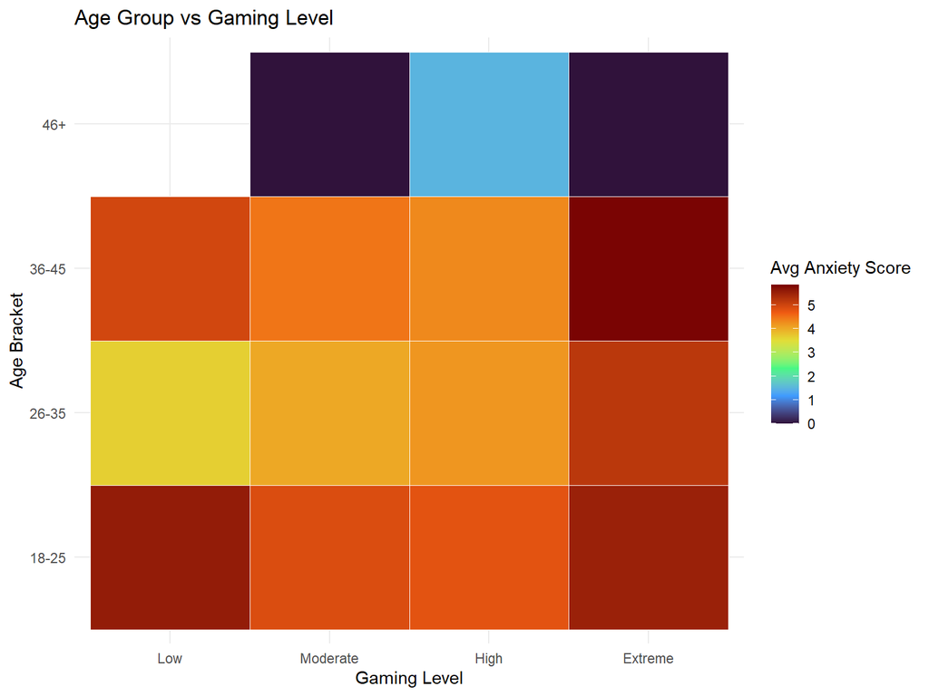

# Key Findings

**Anxiety:** Shows an upward trend in “Extreme” gaming levels.

**Social Context:** Playing with strangers correlates with higher Social Anxiety compared to playing with friends.

**Motivation:** Players gaming for “Relaxation” and “Fun” report higher Life Satisfaction than those gaming for “Competition.”

**Final Thoughts:** Gaming’s effect on well-being depends heavily on how and why you play.

# What does it mean?

- Well-being remains stable through moderate gaming

But in the Extreme category (>30 hours/week) anxiety begins to rise.

Playing with friends results in lower social anxiety than playing with strangers or alone.

- Gamers motivated by fun and relaxation are more satisfied

- Gaming doesn’t affect everyone the same way

Our data suggests the well-being of a gamer is determined by the balance between their gaming hours and their social setting.

# What We Suggest

If you’re playing games, you should pay attention to:

- How much you play
- Who you’re playing with
- Why you’re playing

If all three of these reasons align with actions that don’t bring you stress then your overall well-being will increase rather than decrease.